# OpenAI’s Decisions API, put to a household test

Decision models

# OpenAI’s Decisions API, put to a household test

OpenAI’s new API answers with typed judgements a program can act on, not with chat. One home network asked it which unfamiliar hostnames are ads, alongside TypeSafe’s Jev, two open models that run on your own computer, and a chatbot.

October 2026 · tests run on 18 October

This month OpenAI opened its Decisions API to developers as a public beta. The model behind it, gpt-6-luna, does not write text. You send it a piece of evidence and typed questions, and it sends back probabilities and a confidence that a program can branch on. It has been billed as OpenAI’s answer to TypeSafe’s Jev, the model that made this kind of “decision model” a product.

That made it worth trying on a real problem. On 4 October an ad slipped into an iPhone app on a home network, even though every device there filters its lookups through Pi-hole, a small DNS ad blocker. Pi-hole only blocks hostnames that are already on its blocklists; anything new goes straight through. Jev already runs a weekly check of that household’s unfamiliar hostnames. Could the Decisions API do the job as well?

Each hostname got the same three questions: *which of seven categories fits? how unwanted is it, from 0 to 4? is it run by an ad-tech company?* The test set was 36 hostnames labelled by hand: 18 ad exchanges, 7 trackers and 11 ordinary sites. Jev and two open Strands models answered the same questions, and Anthropic’s Sonnet, a general chatbot, got them in plain English as a reference point. None of them could look anything up; each answered from what it already knew.

### OpenAI Decisions API

OpenAI · model gpt-6-luna · public beta

**Runs**

OpenAI's cloud

**Price**

$0.10 per 1M tokens in, output free

### Jev

TypeSafe · the household's current check

**Runs**

TypeSafe's cloud

**Price**

not published

### Strands 2B

Strands Agents · open weights

**Runs**

on your own computer, offline

**Price**

free

### Strands E4B

Strands Agents · open weights

**Runs**

on your own computer, offline

**Price**

free

### Sonnet

Anthropic · general chatbot

**Runs**

Anthropic's cloud

**Role**

reference only

Start with the 18 ad exchanges: companies whose whole business is serving and auctioning ads. Each row is a hostname, each column a model. **A coloured tile means the model put it in a blocking category**: advertising, tracking or malware.

The Decisions API named a blocking category for all 18.

Jev, the household’s current check, got 17, and Sonnet 18.

The two Strands models are small enough to run on an ordinary computer with no internet connection. They mostly shrugged: a “?” means they answered *unknown*. The 2B model caught 5 and E4B 10.

The one ad exchange Jev let through, `3lift.com`, the Decisions API caught.

Trackers are a harder case: they are mostly analytics companies rather than ad sellers. The Decisions API, Jev and Sonnet each called all 7 of them a tracker or an ad host; the Strands models managed 2 and 4.

For a household, the result that matters most is this one. A wrong block breaks a website, and **none of the five models put any of the 11** ordinary sites **in a blocking category.**

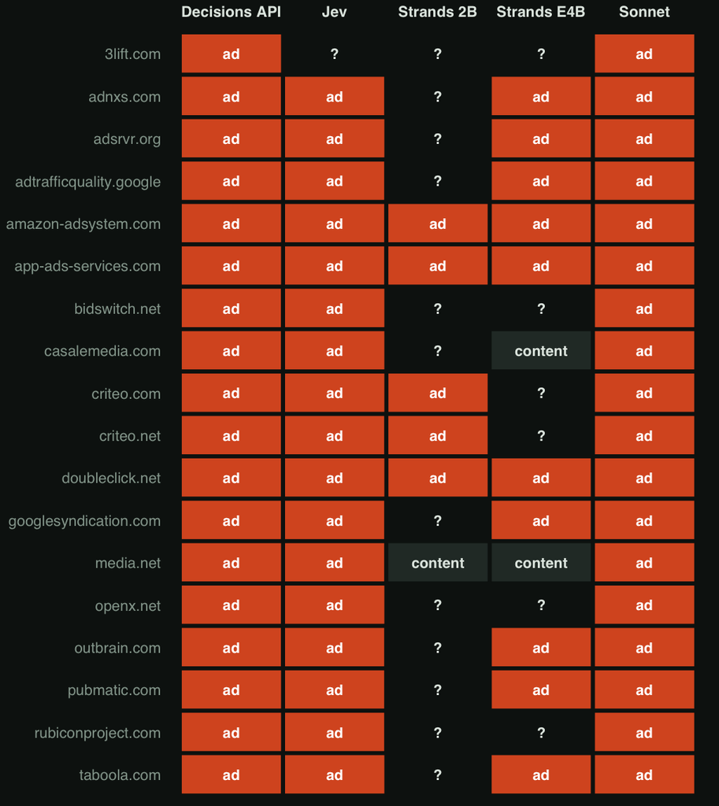

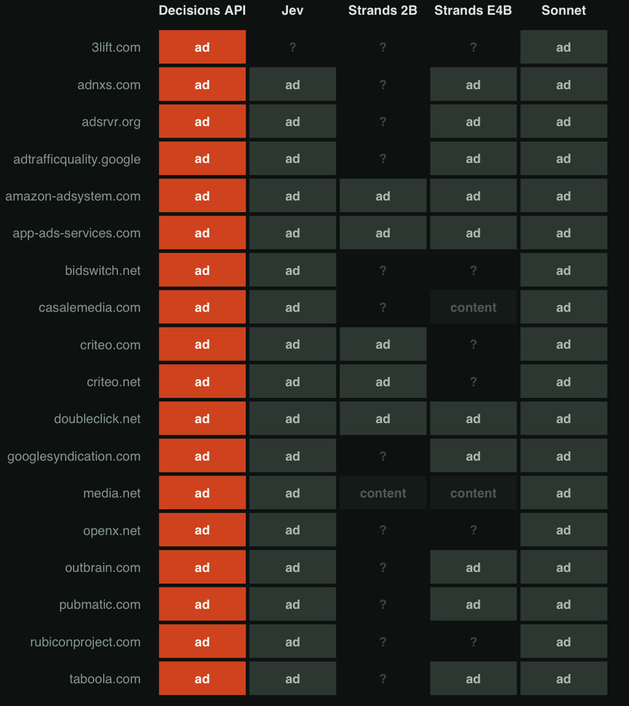

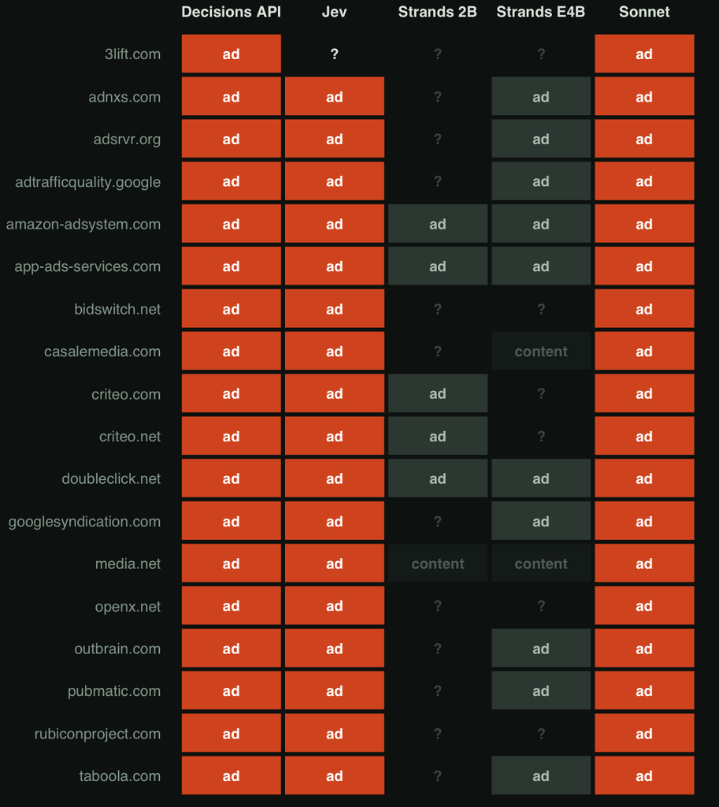

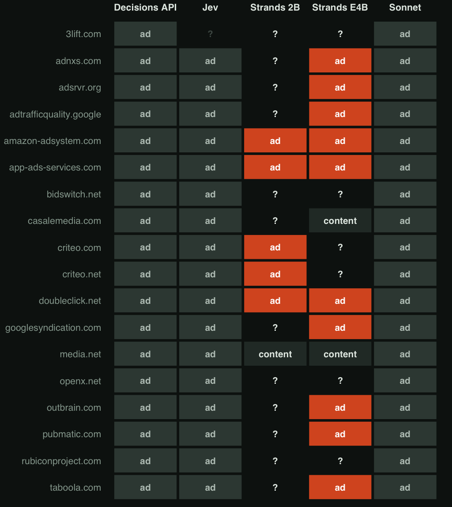

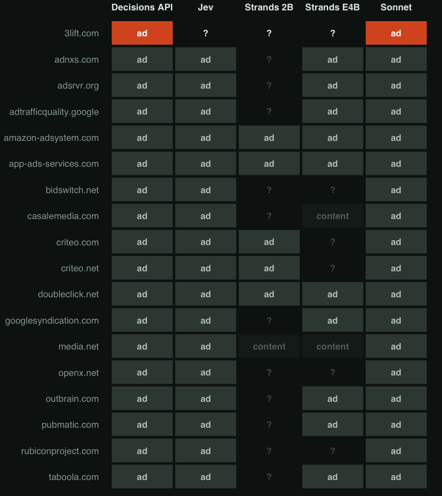

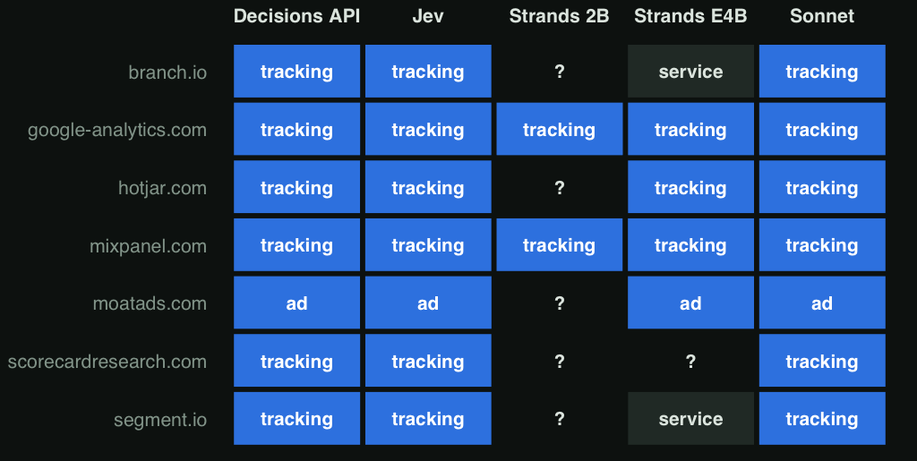

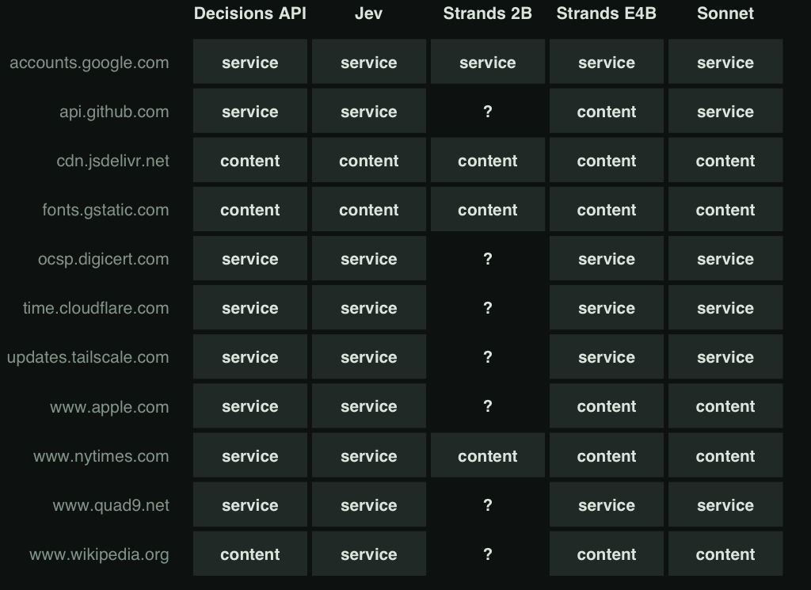

25 of 25

ad and tracker hosts the Decisions API put in a blocking category (Sonnet matched it)

0

ordinary sites it wrongly put in a blocking category

$0.02

what the Decisions API cost for all 263 hostnames tested

0.4 s

its time per hostname, two requests over the network

## How sure is it?

A decision model doesn’t just pick an answer; it says how sure it is. A program can use that to act on the easy cases and send the hard ones to a person. Each model was also asked the category question twice, with the options in reverse order, because a model that leans towards the first option listed will change its answer.

Each dot is one hostname: all 263 that were tested, including the household’s own. The further right, the surer the model was of its category.

The Decisions API was often sure, though less often than Jev: median confidence 0.71, with 93 of 263 hostnames at 0.85 or above. Jev was surer (median 0.81, 125 above 0.85). Reversing the options changed the Decisions API’s category for 19 hostnames and Jev’s for 15.

The Strands models were almost never sure (medians 0.49 and 0.41). A model that is unsure of everything gives a program nothing to act on: every hostname would go to a person.

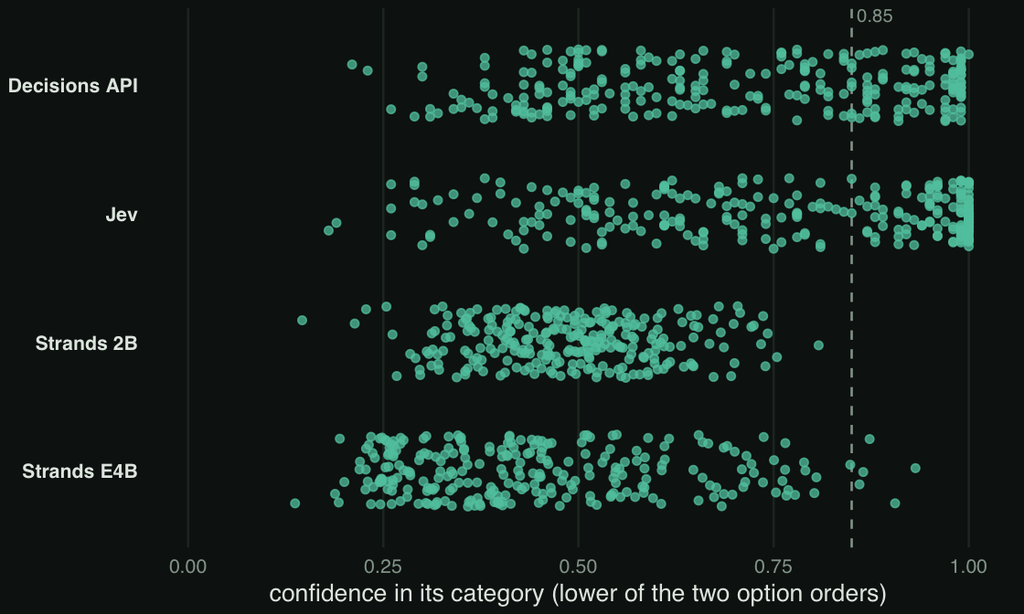

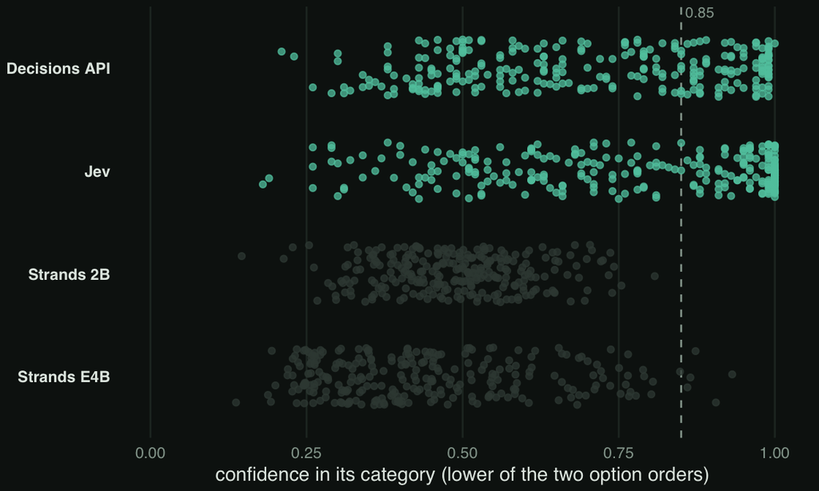

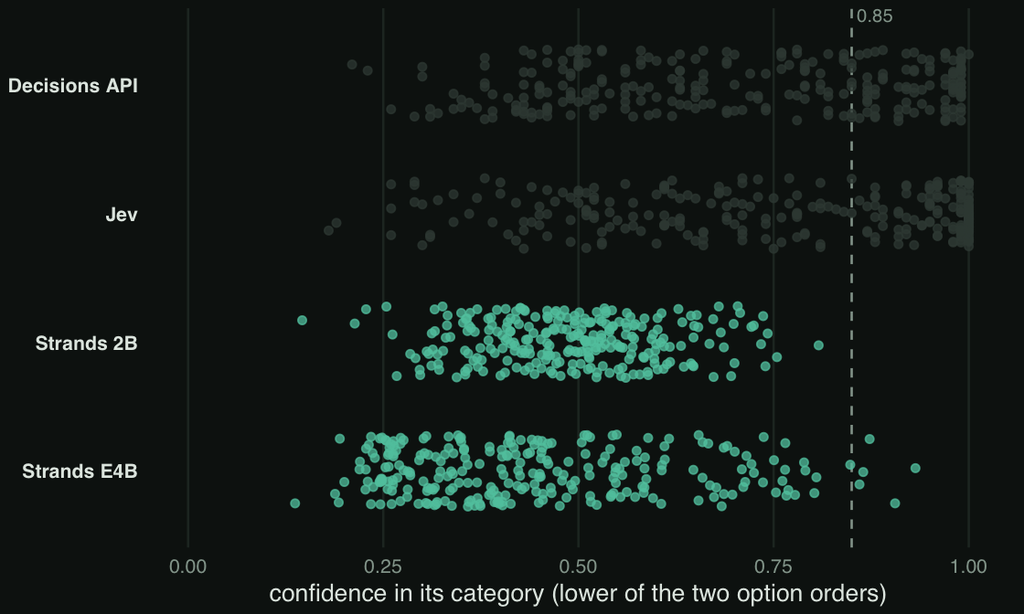

## From answers to decisions

The household’s weekly check doesn’t block on the category alone. It proposes a block only when both option orders agree on a blocking category, with confidence of at least 0.85, **and** one of the other two questions agrees: an unwanted score of 2.5 or more, or an ad-tech answer of 0.5 or more. Anything doubtful goes to a person. The rule never unblocks anything.

Here are the unwanted scores, by model. Ad exchanges sit near 3, *ad serving or tracking*, and ordinary sites near 1.

The trackers sit near 2, which is the scale’s own level for *third-party analytics*. The Decisions API put them at a median of 2.0, below the 2.5 line.

The ad-tech question doesn’t rescue them either. The Decisions API reads it literally: analytics companies aren’t ad-tech, so it put only 2 of the 7 trackers over 0.5. Jev put 5.

So under this rule the Decisions API blocks 16 of the 25 unwanted hostnames automatically and sends 9 to a person, missing 0. Jev blocks 20, sends 4 and misses 1. Neither proposed blocking an ordinary site. The rule’s cut-offs were set for Jev, which is part of why it comes out ahead here.

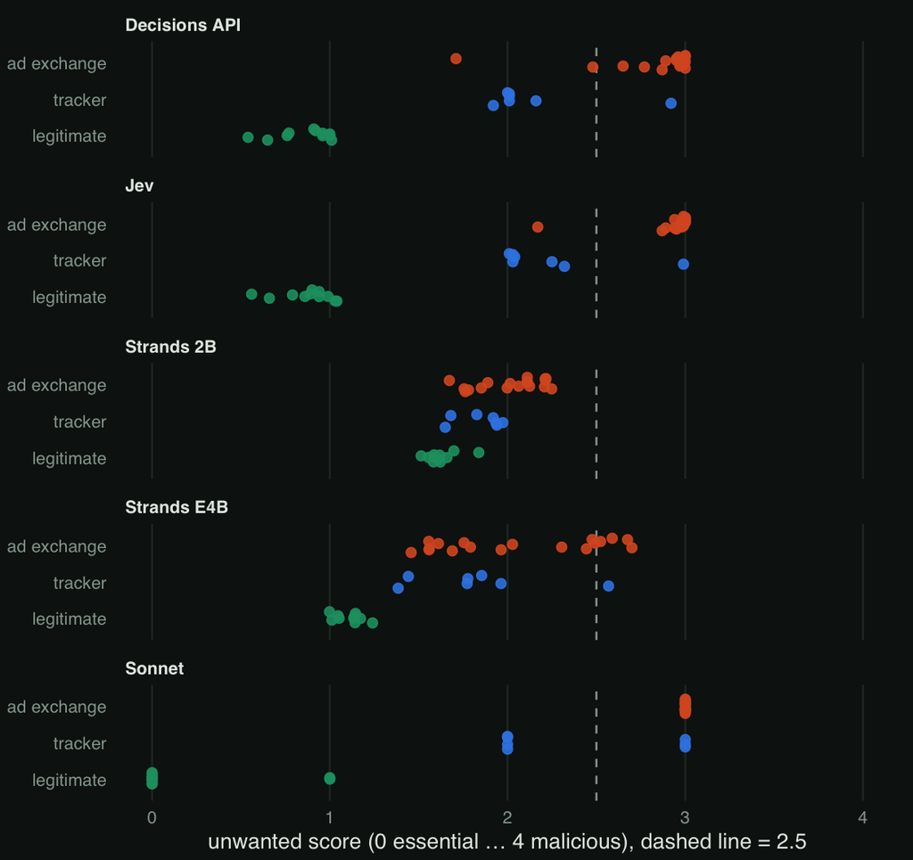

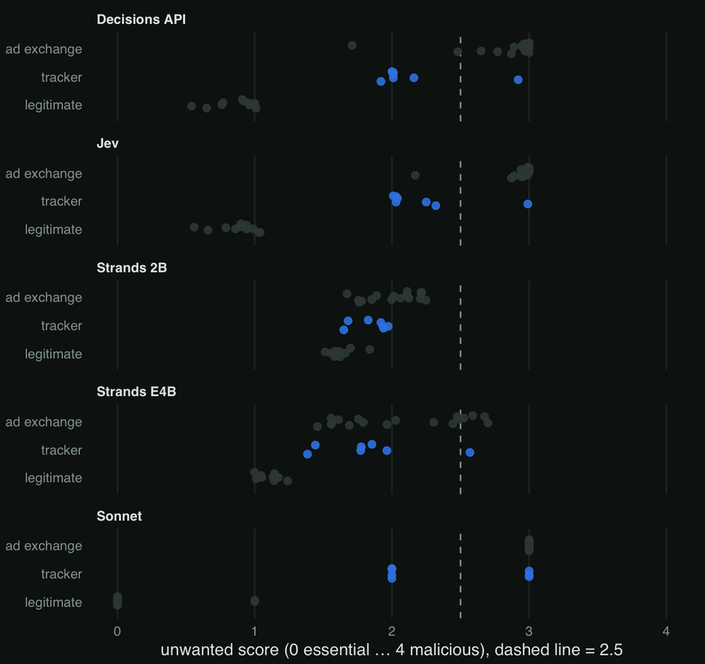

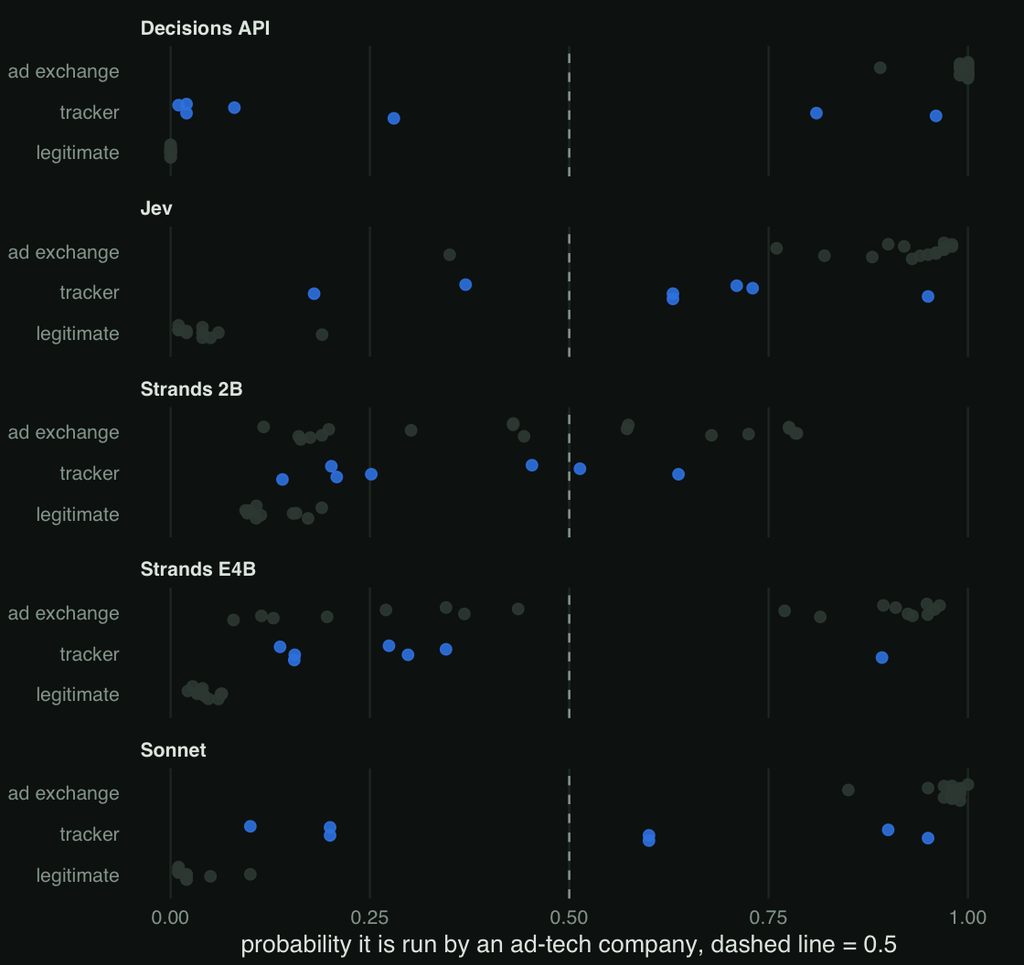

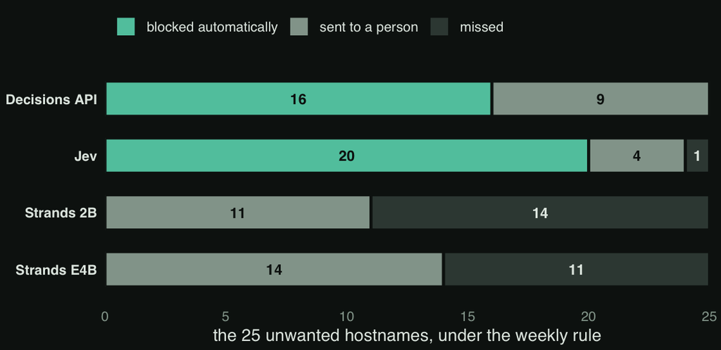

## On the household’s own traffic

The same rule ran over 232 hostnames the household’s devices actually looked up in two recent weeks. There is no answer key for these, so this only shows where the models agree. The hostnames themselves stay private.

209

of the 232 hostnames were left alone by all four decision models

94%

of hostnames where the Decisions API and Jev gave the same verdict

7

hostnames the Decisions API sent to a person (Jev: 18, plus 1 blocked)

0

hostnames it flagged that Jev had left alone

The worst mistake on the household’s traffic came from Strands 2B, which called a well-known app’s own service hostnames malicious, in both option orders. A rule that trusted it would have broken that app.

## Speed, cost and privacy

### OpenAI Decisions API

**Time**

0.42 s per hostname

**Cost**

$0.021 for 263 hostnames

**Sees**

hostnames only

### Jev

**Time**

0.30 s (31 timed)

**Cost**

no published price

**Sees**

hostnames only

### Strands 2B

**Time**

0.66 s on a Mac

**Cost**

free

**Sees**

nothing leaves the computer

### Strands E4B

**Time**

2.29 s on a Mac

**Cost**

free

**Sees**

nothing leaves the computer

### Sonnet

**Time**

1.4 s, one prompt

**Cost**

not priced here

**Sees**

hostnames only

Times are for two requests per hostname (forward and reversed options), except Sonnet’s single prompt. The cloud models’ times include the network. No service was ever sent a device name or an address, only the hostname.

## Was it a fair test?

Mostly, with limits worth knowing.

- **Same inputs.** Every model saw only the hostname and the same questions. None could search the web: Sonnet’s replies record 0 tool uses across all 46.
- **The rule was built for Jev.** The 0.85 and 2.5 cut-offs were set for Jev, before the Decisions API was tested, so the decision-rule results favour Jev. The raw answers in the first section don’t use any rule.
- **Few, famous hostnames.** Thirty-six hand-labelled hostnames, mostly well-known ad companies, is a demonstration, not a benchmark. One or two hostnames either way is noise, and there are no truly hard cases.
- **Sonnet had a different prompt.** It got category names without descriptions, was asked once, and wrote its numbers as text. It’s a reference point, not a contestant.
- **One run each, on different days.** Sonnet answered on 4 October and the decision models mostly on 18 October (some of Jev’s answers date from 4 October). Nobody measured how much each model’s answers vary from run to run.

## What it means

On this test the Decisions API did what it promises. It recognised every ad and tracker host with no false alarms, it was confident often enough for a program to act on, and at $0.02 for 263 hostnames it is cheap. It is also the only model here with a published price.

Its one quirk is that it reads questions literally. Asked whether an analytics company is ad-tech, it says no. Under a rule tuned for Jev, that means fewer automatic blocks and more for a person to review, not more mistakes. Jev stays the household’s weekly check for now, and the Decisions API is a strong second opinion. The small Strands models aren’t ready for this job yet.

Sources: the test results saved on 4 and 18 October 2026. The Decisions API is in public beta, and gpt-6-luna may change before general release. Only the 36 public test hostnames and totals appear on this page. The same results as a short read: Decision Models on a DNS Question.